# Human Activity Recognition

Rod Maclean

May 10, 2016

# INTRODUCTION

Using devices such as Jawbone Up, Nike FuelBand, and Fitbit it is now possible to collect a large amount of data about personal activity relatively inexpensively.This data is commonly used to track how much activity is being performed. This study is designed to assess if the data can be used to show how well the task is being performed.

# DATA

## Initial Cleansing

The training data for this project are available here:

https://d396qusza40orc.cloudfront.net/predmachlearn/pml-training.csv

The test data are available here:

https://d396qusza40orc.cloudfront.net/predmachlearn/pml-testing.csv

The data used was downloaded at 5/10/2016 1:05 PM

```r
library(caret)
library(randomForest)
training <- read.csv("pml-training.csv")
testing  <- read.csv("pml-testing.csv")
```

Using str(training,list.len = 999) we can see there are lots of columns with missing data, and some with values of “#DIV/0!” It is going to be necessary to remove sparsely populated columns and columns with near zero variance.

The first column is an index so we will strip that off immediately

```r
training <- training[,-1]
testing <- testing[,-1]
```

```r
len <- length(training$classe)
na_pct <-sapply(training, function(y) sum(length(which(is.na(y)))))/len
na_pct
```

```
##                user_name     raw_timestamp_part_1     raw_timestamp_part_2
##                0.0000000                0.0000000                0.0000000
##           cvtd_timestamp               new_window               num_window
##                0.0000000                0.0000000                0.0000000
##                roll_belt               pitch_belt                 yaw_belt
##                0.0000000                0.0000000                0.0000000
##         total_accel_belt       kurtosis_roll_belt      kurtosis_picth_belt
##                0.0000000                0.0000000                0.0000000
##        kurtosis_yaw_belt       skewness_roll_belt     skewness_roll_belt.1
##                0.0000000                0.0000000                0.0000000
##        skewness_yaw_belt            max_roll_belt           max_picth_belt
##                0.0000000                0.9793089                0.9793089
##             max_yaw_belt            min_roll_belt           min_pitch_belt
##                0.0000000                0.9793089                0.9793089
##             min_yaw_belt      amplitude_roll_belt     amplitude_pitch_belt
##                0.0000000                0.9793089                0.9793089
##       amplitude_yaw_belt     var_total_accel_belt            avg_roll_belt
##                0.0000000                0.9793089                0.9793089
##         stddev_roll_belt            var_roll_belt           avg_pitch_belt
##                0.9793089                0.9793089                0.9793089
##        stddev_pitch_belt           var_pitch_belt             avg_yaw_belt
##                0.9793089                0.9793089                0.9793089
##          stddev_yaw_belt             var_yaw_belt             gyros_belt_x
##                0.9793089                0.9793089                0.0000000
##             gyros_belt_y             gyros_belt_z             accel_belt_x
##                0.0000000                0.0000000                0.0000000
##             accel_belt_y             accel_belt_z            magnet_belt_x
##                0.0000000                0.0000000                0.0000000
##            magnet_belt_y            magnet_belt_z                 roll_arm
##                0.0000000                0.0000000                0.0000000
##                pitch_arm                  yaw_arm          total_accel_arm
##                0.0000000                0.0000000                0.0000000
##            var_accel_arm             avg_roll_arm          stddev_roll_arm
##                0.9793089                0.9793089                0.9793089
##             var_roll_arm            avg_pitch_arm         stddev_pitch_arm
##                0.9793089                0.9793089                0.9793089
##            var_pitch_arm              avg_yaw_arm           stddev_yaw_arm
##                0.9793089                0.9793089                0.9793089
##              var_yaw_arm              gyros_arm_x              gyros_arm_y
##                0.9793089                0.0000000                0.0000000
```

[output cut: 51 more lines]

```
##                0.9793089                0.9793089                0.0000000
##      total_accel_forearm        var_accel_forearm         avg_roll_forearm
##                0.0000000                0.9793089                0.9793089
##      stddev_roll_forearm         var_roll_forearm        avg_pitch_forearm
##                0.9793089                0.9793089                0.9793089
##     stddev_pitch_forearm        var_pitch_forearm          avg_yaw_forearm
##                0.9793089                0.9793089                0.9793089
##       stddev_yaw_forearm          var_yaw_forearm          gyros_forearm_x
##                0.9793089                0.9793089                0.0000000
##          gyros_forearm_y          gyros_forearm_z          accel_forearm_x
##                0.0000000                0.0000000                0.0000000
##          accel_forearm_y          accel_forearm_z         magnet_forearm_x
##                0.0000000                0.0000000                0.0000000
##         magnet_forearm_y         magnet_forearm_z                   classe
##                0.0000000                0.0000000                0.0000000
```

As we can see there is a pattern where many of the colums have >97% missing values. We will store the remainder in the variable gooodcols and discard the rest.

```r
goodcols <- names (which(na_pct <= .97))
train2 <- training[,goodcols]
goodcols <- c(goodcols, "problem_id" )
test2 <- testing[,goodcols[-92]]
```

We are also going to need to remove the first 6 columns as these are not observations but are part of the measurement metadata.

```r
train3 <- train2[-(1:6)]
test3 <- test2[-(1:6)]
```

Now we will determine the columns with near zero variance and remove these.

```r
nzv <-nearZeroVar(train3,saveMetrics=TRUE)
train4 <- train3[!as.logical(nzv$nzv)]
test4 <- test3[!as.logical(nzv$nzv)]
```

## Cross Validation

We are going to need to try out some models so we will need a cross validation data set. This must be independent from our final test set so it can remain uncontaminated. We will split it 3/4 train and 1/4 test. We will also set a seed to ensure repeatability

```r
set.seed(32123)
TrainInd <- createDataPartition(train4$classe, p=0.75, list = FALSE)
TrainSet <- train4[TrainInd,]
TestSet <- train4[-TrainInd,]
```

First we will try using caret package to perform a repeated Cross Validation random forest fit.

```r
ctrl <- trainControl(method = "repeatedcv", number=10 , repeats = 5)
rf_fit <- train(classe ~ .,
             data = TrainSet,
             method = "rf",
             trControl = ctrl,
             allowParallel=TRUE
             )
```

Now we calculate the out-of-sample error using the 25% test data

```r
ptraining <- predict(rf_fit, TestSet)
print(confusionMatrix(ptraining, TestSet$classe))
```

```
## Confusion Matrix and Statistics
##
##           Reference
## Prediction    A    B    C    D    E
##          A 1393    2    0    0    0
##          B    2  945    5    0    0
##          C    0    2  849   12    1
##          D    0    0    1  792    1
##          E    0    0    0    0  899
##
## Overall Statistics
##
##                Accuracy : 0.9947
##                  95% CI : (0.9922, 0.9965)
##     No Information Rate : 0.2845
##     P-Value [Acc > NIR] : < 2.2e-16
##
##                   Kappa : 0.9933
##  Mcnemar's Test P-Value : NA
##
## Statistics by Class:
##
##                      Class: A Class: B Class: C Class: D Class: E
## Sensitivity            0.9986   0.9958   0.9930   0.9851   0.9978
## Specificity            0.9994   0.9982   0.9963   0.9995   1.0000
## Pos Pred Value         0.9986   0.9926   0.9826   0.9975   1.0000
## Neg Pred Value         0.9994   0.9990   0.9985   0.9971   0.9995
## Prevalence             0.2845   0.1935   0.1743   0.1639   0.1837
## Detection Rate         0.2841   0.1927   0.1731   0.1615   0.1833
## Detection Prevalence   0.2845   0.1941   0.1762   0.1619   0.1833
## Balanced Accuracy      0.9990   0.9970   0.9946   0.9923   0.9989
```

We are going to repeat the training using randomForest package with default values and importance=TRUE. When cross validated with the 25% test set we get the following results:

```r
set.seed(32123)
rfModel <- randomForest(classe ~ ., data = TrainSet, importance = TRUE)
ptraining <- predict(rfModel, TestSet)
print(confusionMatrix(ptraining, TestSet$classe))
```

```
## Confusion Matrix and Statistics
##
##           Reference
## Prediction    A    B    C    D    E
##          A 1392    2    0    0    0
##          B    3  946    4    0    0
##          C    0    1  850    2    0
##          D    0    0    1  802    2
##          E    0    0    0    0  899
##
## Overall Statistics
##
##                Accuracy : 0.9969
##                  95% CI : (0.995, 0.9983)
##     No Information Rate : 0.2845
##     P-Value [Acc > NIR] : < 2.2e-16
##
##                   Kappa : 0.9961
##  Mcnemar's Test P-Value : NA
##
## Statistics by Class:
##
##                      Class: A Class: B Class: C Class: D Class: E
## Sensitivity            0.9978   0.9968   0.9942   0.9975   0.9978
## Specificity            0.9994   0.9982   0.9993   0.9993   1.0000
## Pos Pred Value         0.9986   0.9927   0.9965   0.9963   1.0000
## Neg Pred Value         0.9991   0.9992   0.9988   0.9995   0.9995
## Prevalence             0.2845   0.1935   0.1743   0.1639   0.1837
## Detection Rate         0.2838   0.1929   0.1733   0.1635   0.1833
## Detection Prevalence   0.2843   0.1943   0.1739   0.1642   0.1833
## Balanced Accuracy      0.9986   0.9975   0.9967   0.9984   0.9989
```

This is produces a better fit than the first model.

### Expected Out Of Sample Error

The expected accuracy of the chosen model is 99.69% with 95% confidence between 99.5% and 99.83%

This means we would expect an out of sample error rate of 0.31%.

This figure shows the importance of the predictors used:

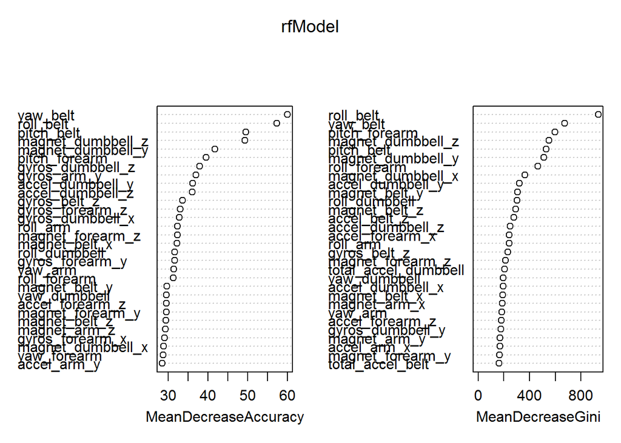

```r
varImpPlot(rfModel)
```

## Final results from supplied test set

These are the predictions from the 20 data sets using the selected model:

```r
ptraining <- as.data.frame(predict(rfModel, test4))
ptraining
```

```
##    predict(rfModel, test4)
## 1                        B
## 2                        A
## 3                        B
## 4                        A
## 5                        A
## 6                        E
## 7                        D
## 8                        B
## 9                        A
## 10                       A
## 11                       B
## 12                       C
## 13                       B
## 14                       A
## 15                       E
## 16                       E
## 17                       A
## 18                       B
## 19                       B
## 20                       B
```

# CONCLUSION

The best fits random forest model has an accuracy of 99.7% which is very high. It is therefore reasonable to conclude that we can accurately measure if an exercise is being poorly performed in one of the five modes modelled.

As described in the original paper, however, there are still a large number of ways that the exercise could be poorly performed that are not included (we only modeled 5), and the model doesn’t take into account combinations of errors either. In reality this approach is not necessarily a scaleable method of correcting exercising errors.